# Project: Investigate a Dataset (Analyzing Movie DB)

- Introduction
- Data Wrangling
- Exploratory Data Analysis
- Conclusions

## Introduction

### Overview

Selected DataSet :**TMDb movie data**

> This data set contains information about **10,000** movies collected from The Movie Database (TMDb),

> Each record has : **TMovie ID, imdb ID, popularity, budget, revenue, original title, cast, homepage, director, tagline, overview, runtime, genres, production companies, release date, vote count, vote average, release year, budget adj, revenue adj**

##### **Question that will be solved:**

> 1- What is the most loved Generes?

> 2- Is there a relation between the movie success and the Run time?

> 3- what is the most proftiable year quarter ? the year has 4 quarters and every quarter last for 3 months

```python
# Use this cell to set up import statements for all of the packages that you
#   plan to use.
import pandas as pd
import matplotlib.pyplot as plt
% matplotlib inline
```

## Data Wrangling

### General Properties

```python
# Load your data and print out a few lines. Perform operations to inspect data
#   types and look for instances of missing or possibly errant data.
tmdb = pd.read_csv('tmdb-movies.csv')
tmdb.head(3)
```

|  | id | imdb_id | popularity | budget | revenue | original_title | cast | homepage | director | tagline | ... | overview | runtime | genres | production_companies | release_date | vote_count | vote_average | release_year | budget_adj | revenue_adj |
| --- | --- | --- | --- | --- | --- | --- | --- | --- | --- | --- | --- | --- | --- | --- | --- | --- | --- | --- | --- | --- | --- |
| 0 | 135397 | tt0369610 | 32.985763 | 150000000 | 1513528810 | Jurassic World | Chris Pratt\|Bryce Dallas Howard\|Irrfan Khan\|Vi... | http://www.jurassicworld.com/ | Colin Trevorrow | The park is open. | ... | Twenty-two years after the events of Jurassic ... | 124 | Action\|Adventure\|Science Fiction\|Thriller | Universal Studios\|Amblin Entertainment\|Legenda... | 6/9/15 | 5562 | 6.5 | 2015 | 1.379999e+08 | 1.392446e+09 |
| 1 | 76341 | tt1392190 | 28.419936 | 150000000 | 378436354 | Mad Max: Fury Road | Tom Hardy\|Charlize Theron\|Hugh Keays-Byrne\|Nic... | http://www.madmaxmovie.com/ | George Miller | What a Lovely Day. | ... | An apocalyptic story set in the furthest reach... | 120 | Action\|Adventure\|Science Fiction\|Thriller | Village Roadshow Pictures\|Kennedy Miller Produ... | 5/13/15 | 6185 | 7.1 | 2015 | 1.379999e+08 | 3.481613e+08 |
| 2 | 262500 | tt2908446 | 13.112507 | 110000000 | 295238201 | Insurgent | Shailene Woodley\|Theo James\|Kate Winslet\|Ansel... | http://www.thedivergentseries.movie/#insurgent | Robert Schwentke | One Choice Can Destroy You | ... | Beatrice Prior must confront her inner demons ... | 119 | Adventure\|Science Fiction\|Thriller | Summit Entertainment\|Mandeville Films\|Red Wago... | 3/18/15 | 2480 | 6.3 | 2015 | 1.012000e+08 | 2.716190e+08 |

3 rows × 21 columns

### Data Cleaning

**First** we remove the columns that there is no need for them in the analysis such as imdb_id, cast, homepage, director, overview, tagline, keywords, production_companies, budget_adj, revenue_adj, original_title, budget,

```python
tmdb.drop(['imdb_id','cast','homepage','director','overview','tagline','keywords','budget_adj','revenue_adj','production_companies','original_title','budget'],axis=1,inplace=True)
tmdb.head(1)
```

|  | id | popularity | revenue | runtime | genres | release_date | vote_count | vote_average | release_year |
| --- | --- | --- | --- | --- | --- | --- | --- | --- | --- |
| 0 | 135397 | 32.985763 | 1513528810 | 124 | Action\|Adventure\|Science Fiction\|Thriller | 6/9/15 | 5562 | 6.5 | 2015 |

**Second** remove dublicated records if exists

```python
tmdb.shape
```

```
(10866, 9)
```

```python
tmdb.drop_duplicates(keep ='first', inplace=True)
tmdb.shape
```

```
(10865, 9)
```

there exist a dublicated record and its now removed

**Third** remove Na records

```python
#remove rows with NA
tmdb.dropna(inplace=True)

tmdb.shape
```

```
(10842, 9)
```

there exist some columns with NaN value and its now removed

```python
tmdb.describe(include = 'all')
```

|  | id | popularity | revenue | runtime | genres | release_date | vote_count | vote_average | release_year |
| --- | --- | --- | --- | --- | --- | --- | --- | --- | --- |
| count | 10842.000000 | 10842.000000 | 1.084200e+04 | 10842.000000 | 10842 | 10842 | 10842.000000 | 10842.000000 | 10842.000000 |
| unique | NaN | NaN | NaN | NaN | 2039 | 5904 | NaN | NaN | NaN |
| top | NaN | NaN | NaN | NaN | Drama | 1/1/09 | NaN | NaN | NaN |
| freq | NaN | NaN | NaN | NaN | 712 | 28 | NaN | NaN | NaN |
| mean | 65870.675521 | 0.647461 | 3.991138e+07 | 102.138443 | NaN | NaN | 217.823649 | 5.974064 | 2001.314794 |
| std | 91981.355752 | 1.001032 | 1.171179e+08 | 31.294612 | NaN | NaN | 576.180993 | 0.934257 | 12.813617 |
| min | 5.000000 | 0.000065 | 0.000000e+00 | 0.000000 | NaN | NaN | 10.000000 | 1.500000 | 1960.000000 |
| 25% | 10589.250000 | 0.208210 | 0.000000e+00 | 90.000000 | NaN | NaN | 17.000000 | 5.400000 | 1995.000000 |
| 50% | 20557.000000 | 0.384532 | 0.000000e+00 | 99.000000 | NaN | NaN | 38.000000 | 6.000000 | 2006.000000 |
| 75% | 75186.000000 | 0.715393 | 2.414118e+07 | 111.000000 | NaN | NaN | 146.000000 | 6.600000 | 2011.000000 |
| max | 417859.000000 | 32.985763 | 2.781506e+09 | 900.000000 | NaN | NaN | 9767.000000 | 9.200000 | 2015.000000 |

```python
tmdb.info()
```

```
<class 'pandas.core.frame.DataFrame'>
Int64Index: 10842 entries, 0 to 10865
Data columns (total 9 columns):
id              10842 non-null int64
popularity      10842 non-null float64
revenue         10842 non-null int64
runtime         10842 non-null int64
genres          10842 non-null object
release_date    10842 non-null object
vote_count      10842 non-null int64
vote_average    10842 non-null float64
release_year    10842 non-null int64
dtypes: float64(2), int64(5), object(2)
memory usage: 847.0+ KB
```

**Forth** change data type of release date to date time

```python
tmdb.release_date = pd.to_datetime(tmdb['release_date'])
tmdb.info()
```

```
<class 'pandas.core.frame.DataFrame'>
Int64Index: 10842 entries, 0 to 10865
Data columns (total 9 columns):
id              10842 non-null int64
popularity      10842 non-null float64
revenue         10842 non-null int64
runtime         10842 non-null int64
genres          10842 non-null object
release_date    10842 non-null datetime64[ns]
vote_count      10842 non-null int64
vote_average    10842 non-null float64
release_year    10842 non-null int64
dtypes: datetime64[ns](1), float64(2), int64(5), object(1)
memory usage: 847.0+ KB
```

**Fifth** seprate Genere record to new sperete records

```python
def seperate_col_to_rows(df,col,separator,id):
    """Return the dataframe after seperating the col with the separator to new rows indexing by id """
    #transfer list to rows after seperation
    df=df.copy()
    new_df = pd.DataFrame(df[col].str.split(separator).tolist(),index=df[id]).stack()
    #reset index using id
    new_df = new_df.reset_index([0, id])
    new_df.columns=[id,col]
    #drop old col
    df.drop([col],axis=1,inplace=True)
    #merge new col with the dataset
    df=pd.merge(df,new_df,how='inner',left_on=id, right_on=id)

    return df

#seprate genre col to rows
tmdb_genre=seperate_col_to_rows(tmdb,'genres','|','id')


tmdb_genre.head()
```

|  | id | popularity | revenue | runtime | release_date | vote_count | vote_average | release_year | genres |
| --- | --- | --- | --- | --- | --- | --- | --- | --- | --- |
| 0 | 135397 | 32.985763 | 1513528810 | 124 | 2015-06-09 | 5562 | 6.5 | 2015 | Action |
| 1 | 135397 | 32.985763 | 1513528810 | 124 | 2015-06-09 | 5562 | 6.5 | 2015 | Adventure |
| 2 | 135397 | 32.985763 | 1513528810 | 124 | 2015-06-09 | 5562 | 6.5 | 2015 | Science Fiction |
| 3 | 135397 | 32.985763 | 1513528810 | 124 | 2015-06-09 | 5562 | 6.5 | 2015 | Thriller |
| 4 | 76341 | 28.419936 | 378436354 | 120 | 2015-05-13 | 6185 | 7.1 | 2015 | Action |

## Exploratory Data Analysis

### Research Question 1 (What is the most loved Generes?)

```python
#categories
tmdb_genre['genres'].unique()
```

```
array(['Action', 'Adventure', 'Science Fiction', 'Thriller', 'Fantasy',
       'Crime', 'Western', 'Drama', 'Family', 'Animation', 'Comedy',
       'Mystery', 'Romance', 'War', 'History', 'Music', 'Horror',
       'Documentary', 'TV Movie', 'Foreign'], dtype=object)
```

```python
tmdb_genre_plot=tmdb_genre.groupby('genres').sum().iloc[:,[1]]

#sort the result
tmdb_genre_plot.sort_values(by = ['popularity'],inplace=True, ascending=[False])
tmdb_genre_plot
```

| genres | popularity |
| --- | --- |
| Drama | 2815.517715 |
| Comedy | 2247.759649 |
| Action | 2208.238255 |
| Thriller | 2155.723620 |
| Adventure | 1697.915054 |
| Science Fiction | 1230.902062 |
| Romance | 1013.644468 |
| Crime | 1008.635823 |
| Family | 968.388793 |
| Fantasy | 909.441171 |
| Horror | 761.788804 |
| Animation | 595.674975 |
| Mystery | 558.909827 |
| Music | 198.827043 |
| War | 196.474450 |
| History | 192.362605 |
| Western | 97.451554 |
| Documentary | 94.344445 |
| TV Movie | 45.239592 |
| Foreign | 36.001309 |

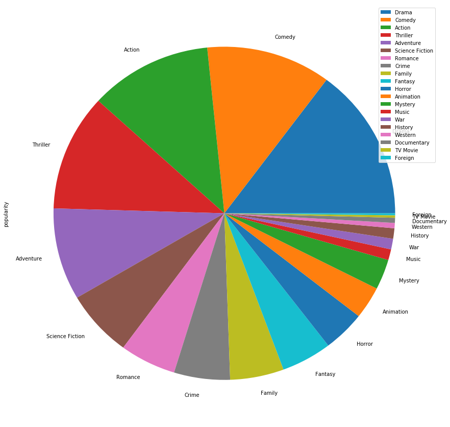

```python
tmdb_genre_plot.plot(kind='pie',y='popularity',figsize=(15, 15))
```

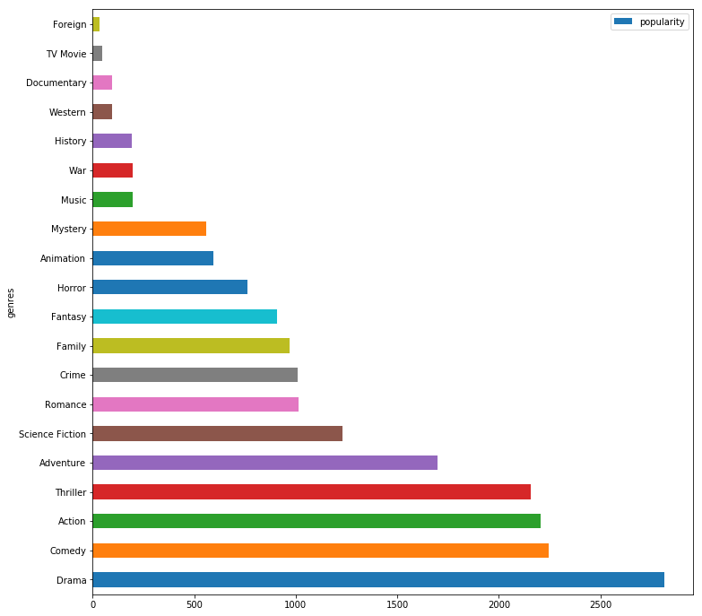

```python
tmdb_genre_plot.plot(kind='barh',y='popularity',figsize=(12, 12))
```

As the result: the most beloved gere is Drama followed by Comedy

### Research Question 2 (Is there a relation between the movie success and the Run time?)

**First** explore data by using plotting

[output not shown]

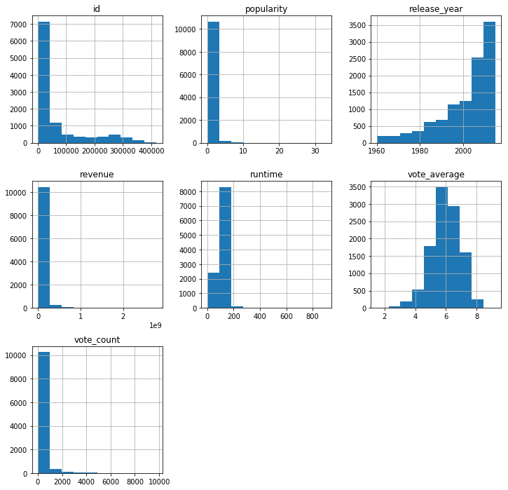

```python
tmdb.hist(figsize=(12, 12))
```

we see from the histograms that the number of movies increased dramatically lately !

[output not shown]

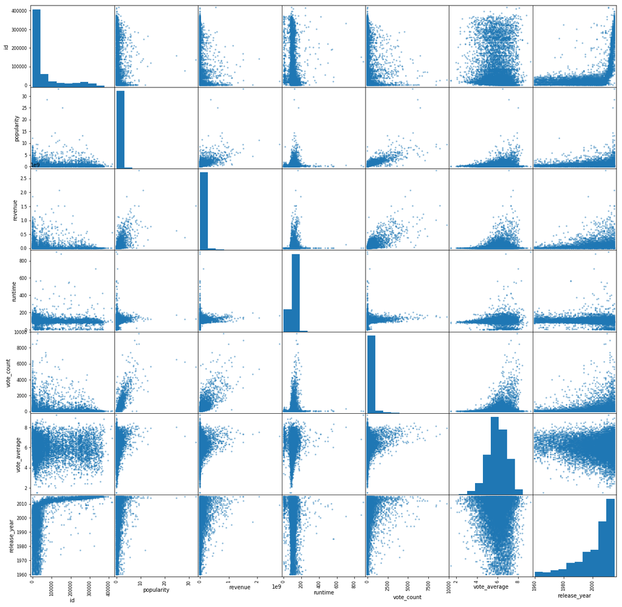

```python
pd.plotting.scatter_matrix(tmdb,figsize=(20, 20) )
```

to evaulate how success the movie is, I will use the revenue, popularity and vote_avg

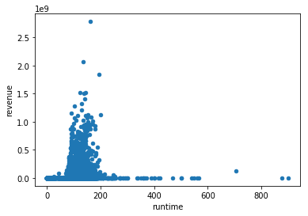

```python
tmdb.plot(kind='scatter',x='runtime',y='revenue')
```

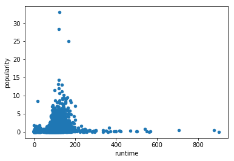

```python
tmdb.plot(kind='scatter',x='runtime',y='popularity')
```

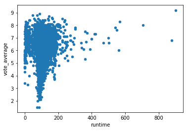

```python
tmdb.plot(kind='scatter',x='runtime',y='vote_average')
```

```python
tmdb.runtime.mean()
```

```
102.1384430916805
```

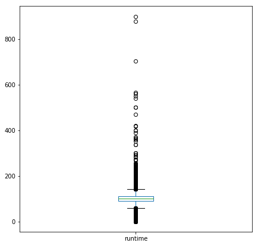

```python
tmdb.plot(kind='box',y='runtime',figsize=(7, 7))
```

Also there are alot of liars in the watch time which could affect the results, so I will remove the records with run time more than 240 min which is 4 hours

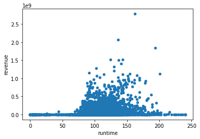

```python
tmdb=tmdb[tmdb['runtime']<=240]
tmdb.plot(kind='scatter',x='runtime',y='revenue')
```

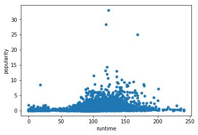

```python
tmdb.plot(kind='scatter',x='runtime',y='popularity')
```

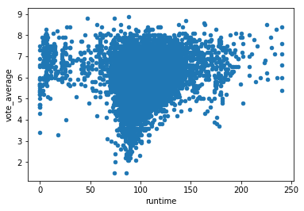

```python
tmdb.plot(kind='scatter',x='runtime',y='vote_average')
```

it appears runtime from 80 to 150 min is the best

revenu and popularity apply normal distrubtion which mean the longer the movie will not be popular and not gain high revenue

### Research Question 3 (what is the most proftiable year quarter ?)

```python
tmdb_season=tmdb.loc[:,['release_date','revenue']]
tmdb_season.head()
q1=tmdb_season[(tmdb_season['release_date'].dt.month >= 1 )& (tmdb_season['release_date'].dt.month <= 3)]
q2=tmdb_season[(tmdb_season['release_date'].dt.month >= 4 )& (tmdb_season['release_date'].dt.month <= 6)]
q3=tmdb_season[(tmdb_season['release_date'].dt.month >= 7 )& (tmdb_season['release_date'].dt.month <= 9)]
q4=tmdb_season[(tmdb_season['release_date'].dt.month >= 10 )& (tmdb_season['release_date'].dt.month <= 12)]

q1=q1.sum()
q2=q2.sum()
q3=q3.sum()
q4=q4.sum()
tmdb_season=pd.DataFrame(data=[['q1', q1['revenue']], ['q2', q2['revenue']],['q3', q3['revenue']], ['q4', q4['revenue']]],columns=['quarter','revene_total'])

tmdb_season
```

|  | quarter | revene_total |
| --- | --- | --- |
| 0 | q1 | 64157211830 |
| 1 | q2 | 138450090425 |
| 2 | q3 | 96466472674 |
| 3 | q4 | 133436829667 |

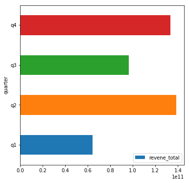

```python
tmdb_season.plot(kind='barh',y='revene_total',x='quarter',figsize=(6, 6))
```

quarter 2 and 4 has the heighst revenue over all years!

## Conclusions

> Drama has the highest popularity

> The movies released in the second and forth quarter has the highest revenue over all years

```python
from subprocess import call
call(['python', '-m', 'nbconvert', 'Investigate_a_Dataset.ipynb'])
```

```
0
```